# DA Mini Project

- 주제 : 온라인 학습 플랫폼 사용자 행동 패턴 분석
- 개요 : ``` 이번 프로젝트는 학습 서비스를 이용하는 독자들 중 누가 서비스 구독을 연장할지 예측하기 위한 사전 파악에 초점을 맞추고 있습니다. 우리의 목표는 유저들의 학습 습관, 선호도, 이용 행태 등 다양한 측면을 면밀히 분석하는 것입니다.

이를 위해, 우리는 유저들의 학습 패턴, 서비스 이용 시간, 콘텐츠에 대한 반응, 그리고 이들이 얼마나 자주 서비스를 이용하는지 등 다양한 데이터를 수집하고 분석할 계획입니다. 이 데이터는 유저들이 서비스에 얼마나 만족하고 있는지, 어떤 요소들이 그들의 구독 결정에 영향을 미치는지 이해하는 데 중요한 역할을 할 것입니다. ```

- 데이터셋 : mini.csv
  - 메타데이터
    - user_id: 사용자의 고유 식별자
    - subscription_duration: 사용자가 서비스에 가입한 기간 (월)
    - recent_login_time: 사용자가 마지막으로 로그인한 시간 (일)
    - average_login_time: 사용자의 일반적인 로그인 시간
    - average_time_per_learning_session: 각 학습 세션에 소요된 평균 시간 (분)
    - monthly_active_learning_days: 월간 활동적인 학습 일수
    - total_completed_courses: 완료한 총 코스 수
    - recent_learning_achievement: 최근 학습 성취도
    - abandoned_learning_sessions: 중단된 학습 세션 수
    - community_engagement_level: 커뮤니티 참여도
    - preferred_difficulty_level: 선호하는 난이도
    - subscription_type: 구독 유형
    - customer_inquiry_history: 고객 문의 이력
    - payment_pattern : 사용자의 지난 3개월 간의 결제 패턴을 10진수로 표현한 값.
      - 7: 3개월 모두 결제함
      - 6: 첫 2개월은 결제했으나 마지막 달에는 결제하지 않음
      - 5: 첫 달과 마지막 달에 결제함
      - 4: 첫 달에만 결제함
      - 3: 마지막 2개월에 결제함
      - 2: 가운데 달에만 결제함
      - 1: 마지막 달에만 결제함
      - 0: 3개월 동안 결제하지 않음
      - target: 사용자가 다음 달에도 구독을 계속할지 (1) 또는 취소할지 (0)를 나타냄
- 의문점
  - 학습 서비스를 이용하는 독자?  
    → 학습 플랫폼이면 독자보다는 이용자나 수강생이라는 워딩을 쓰지 않나?

```python
import pandas as pd
import numpy as np
import matplotlib.pyplot as plt
import seaborn as sns
import koreanize_matplotlib
```

```python
df = pd.read_csv('./data/mini.csv',encoding = 'cp949')
```

# 결제 패턴(payment_pattern)

1. 중간에 구독을 끊었던 사람이 다시 구독을 한 것은 무엇일까?  
   -> 개인적인 사정, 자신이 원하는 콘텐츠가 들어옴, 자신이 문의한 상황의 해결  
   -> 고객 문의 이력을 볼까?

## 현재의 payment_type은 보기 불편하므로 바꿔보자

```
payment_type은 지난 3달 간의 결제 내역이므로
- last3 : 첫 달
- last2 : 가운데 달
- last1 : 마지막 달
```

```python
df['last3'] = "" ; df['last2'] = "" ; df['last1'] ="" ;

payment_pattern = [
    [0,0,0], #0
    [0,0,1], #1
    [0,1,0], #2
    [0,1,1], #3
    [1,0,0], #4
    [1,0,1], #5
    [1,1,0], #6
    [1,1,1] #7
]

for pattern in range(0,8):
    mask = (df['payment_pattern']== pattern)
    # category 형태로 만들기 위해서
    df['last3'][mask] = str(payment_pattern[pattern][0])
    df['last2'][mask] = str(payment_pattern[pattern][1])
    df['last1'][mask] = str(payment_pattern[pattern][2])
```

[output not shown]

[output cut: 65 more lines]

[output not shown]

```python
df.groupby(['last3','last2','last1','target'])[['user_id']].count()
```

| last3 | last2 | last1 | target | user_id |
| --- | --- | --- | --- | --- |
| 0 | 0 | 0 | 구독 연장 예정 | 807 |
|  |  |  | 구독 취소 예정 | 468 |
|  |  | 1 | 구독 연장 예정 | 783 |
|  |  |  | 구독 취소 예정 | 502 |
|  | 1 | 0 | 구독 연장 예정 | 747 |
|  |  |  | 구독 취소 예정 | 459 |
|  |  | 1 | 구독 연장 예정 | 763 |
|  |  |  | 구독 취소 예정 | 467 |
| 1 | 0 | 0 | 구독 연장 예정 | 753 |
|  |  |  | 구독 취소 예정 | 461 |
|  |  | 1 | 구독 연장 예정 | 750 |
|  |  |  | 구독 취소 예정 | 488 |
|  | 1 | 0 | 구독 연장 예정 | 801 |
|  |  |  | 구독 취소 예정 | 467 |
|  |  | 1 | 구독 연장 예정 | 795 |
|  |  |  | 구독 취소 예정 | 489 |

```python
df.groupby(['last3','last2','last1'])[['user_id']].count()
```

| last3 | last2 | last1 | user_id |
| --- | --- | --- | --- |
| 0 | 0 | 0 | 1275 |
|  |  | 1 | 1285 |
|  | 1 | 0 | 1206 |
|  |  | 1 | 1230 |
| 1 | 0 | 0 | 1214 |
|  |  | 1 | 1238 |
|  | 1 | 0 | 1268 |
|  |  | 1 | 1284 |

```python
df['payment_type'] = df['last3']+df['last2']+df['last1']
df['payment_type'].head(10)
```

```
0    101
1    110
2    111
3    000
4    000
5    111
6    110
7    001
8    000
9    111
Name: payment_type, dtype: object
```

```python
df[['payment_type']].value_counts()
# payment_type별로 사람의 차이가 크게 나지 않음 -> 사람 수에 인한 변인은 어느 정도 무시 가능
```

```
payment_type
001             1285
111             1284
000             1275
110             1268
101             1238
011             1230
100             1214
010             1206
Name: count, dtype: int64
```

```
[]
```

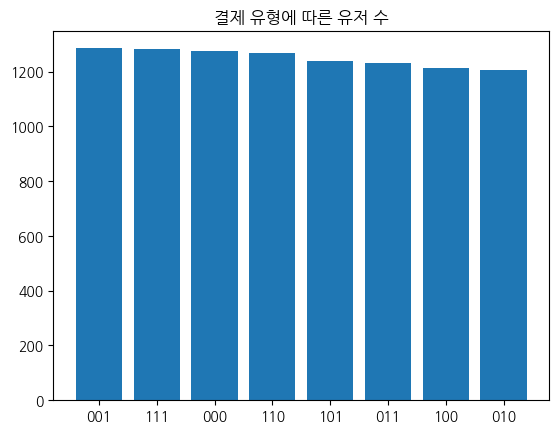

```python
plt.bar(df['payment_type'].value_counts().index,df['payment_type'].value_counts())
plt.title('결제 유형에 따른 유저 수')
plt.plot()
```

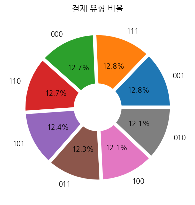

```python
wedgeprops={'width': 0.7, 'edgecolor': 'w', 'linewidth': 5}
plt.pie(df['payment_type'].value_counts(),autopct = '%.1f%%',
        labels = df['payment_type'].value_counts().index,
       wedgeprops = wedgeprops)
plt.title('결제 유형 비율')
plt.show()
```

```python
pd.pivot_table(df,
              index = 'subscription_duration',
              columns = 'payment_type',
              values = 'user_id',
              aggfunc = 'count').head()
```

| payment_type subscription_duration | 000 | 001 | 010 | 011 | 100 | 101 | 110 | 111 |
| --- | --- | --- | --- | --- | --- | --- | --- | --- |
| 1 | 55 | 58 | 50 | 47 | 62 | 51 | 60 | 53 |
| 2 | 54 | 59 | 51 | 49 | 67 | 56 | 45 | 62 |
| 3 | 47 | 57 | 61 | 43 | 50 | 52 | 51 | 47 |
| 4 | 67 | 52 | 57 | 55 | 53 | 68 | 67 | 56 |
| 5 | 52 | 57 | 54 | 56 | 54 | 38 | 46 | 67 |

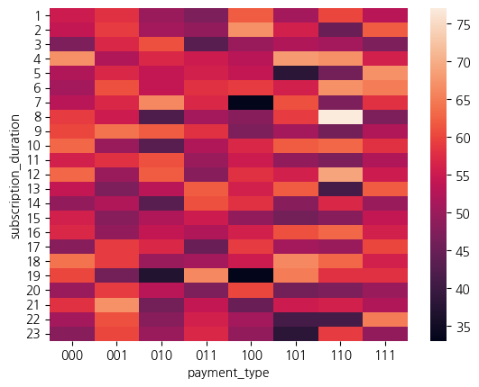

```python
sns.heatmap(pd.pivot_table(df,
              index = 'subscription_duration',
              columns = 'payment_type',
              values = 'user_id',
              aggfunc = 'count'))
```

### 데이터에서 이상한 점

- 위의 데이터는 payment_type의 결제가 구독을 결제한다는 가설을 지니고 만든 데이터이다.
- 하지만, payment가 구독이라면 '111'은 지난 3개월간 구독을 결제한 사람이나, 그렇다면 subscription_duration이 1일 수가 없음 ('111'인 사람의 subscription_duration은 최소 3이상이어야 한다)  
  => payment와 subscrption은 별개의 무언가  
  => 구독 유형을 살펴보자

### 구독 유형

```python
df[['subscription_type']].value_counts() # 구독 유형은 basic과 premium 두가지
```

```
subscription_type
Basic                5979
Premium              4021
Name: count, dtype: int64
```

#### premium 구독 결제가 따로 있는가? -> △

- 중간에 basic이나 premium으로 전환했을 수 있으나... 이 데이터에서는 알 수 없음  
  => 일단 학습은 Basic이든 Premium이든 모두 할 수 있는 서비스

```python
pd.pivot_table(df,
              index = 'subscription_type',
              columns = 'payment_type',
              values = 'user_id',
              aggfunc = 'count')
```

| payment_type subscription_type | 000 | 001 | 010 | 011 | 100 | 101 | 110 | 111 |
| --- | --- | --- | --- | --- | --- | --- | --- | --- |
| Basic | 763 | 722 | 697 | 714 | 764 | 772 | 766 | 781 |
| Premium | 512 | 563 | 509 | 516 | 450 | 466 | 502 | 503 |

### monthly_active_learning_days와 결제가 연관이 있나? -> X

[output not shown]

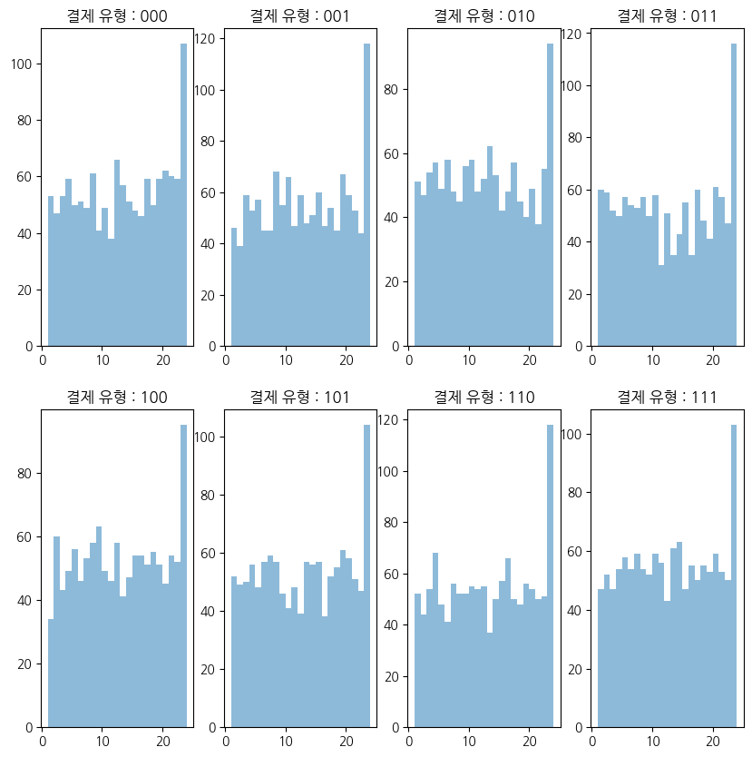

```python
fig, axes = plt.subplots(2,4,figsize= (10,10))
axes = axes.ravel()

i=0
for payment_type, subset in df.groupby('payment_type'):
    axes[i].hist(subset['monthly_active_learning_days'],bins = range(1,25),alpha = 0.5, label = payment_type)
    axes[i].set_title(f"결제 유형 : {payment_type}")
    i += 1
plt.show()
```

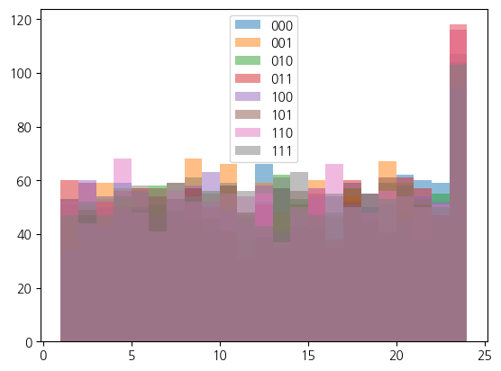

```python
for payment_type, subset in df.groupby('payment_type'):
    plt.hist(subset['monthly_active_learning_days'],bins = range(1,25),alpha = 0.5, label = payment_type)
plt.legend()
plt.show()
```

```python
"""pd.pivot_table(df,
              index = 'monthly_active_learning_days',
              columns = 'payment_type',
              values = 'user_id',
              aggfunc = 'count')"""
```

[output not shown]

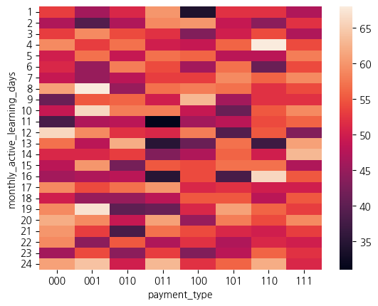

```python
sns.heatmap(pd.pivot_table(df,
              index = 'monthly_active_learning_days',
              columns = 'payment_type',
              values = 'user_id',
              aggfunc = 'count')

)
```

### 결제를 안 하면 학습 시간에 제약이 있나? -> X

```python
cut_bins = np.arange(0,540,30) # 30분 간격으로 학습 시간을 끊기
interval = list(map(lambda x: int(x), np.arange(1,18)))
df['avg_time_interval'] = pd.cut(df['average_time_per_learning_session'],bins = cut_bins,labels = interval)
```

```python
pd.pivot_table(df,
              index = 'avg_time_interval',
              columns = 'payment_type',
              values = 'user_id',
              aggfunc = 'count') #데이터가 깔끔하당...
```

| payment_type avg_time_interval | 000 | 001 | 010 | 011 | 100 | 101 | 110 | 111 |
| --- | --- | --- | --- | --- | --- | --- | --- | --- |
| 1 | 551 | 548 | 497 | 526 | 502 | 538 | 545 | 547 |
| 2 | 311 | 287 | 300 | 306 | 287 | 291 | 313 | 333 |
| 3 | 184 | 190 | 185 | 148 | 172 | 172 | 161 | 179 |
| 4 | 96 | 99 | 106 | 105 | 97 | 101 | 109 | 86 |
| 5 | 65 | 54 | 42 | 55 | 68 | 58 | 65 | 48 |
| 6 | 31 | 42 | 30 | 34 | 31 | 35 | 30 | 38 |
| 7 | 14 | 33 | 26 | 18 | 23 | 17 | 20 | 23 |
| 8 | 9 | 11 | 12 | 17 | 16 | 7 | 15 | 10 |
| 9 | 9 | 4 | 2 | 4 | 7 | 6 | 4 | 7 |
| 10 | 2 | 6 | 3 | 11 | 2 | 4 | 3 | 5 |
| 11 | 0 | 2 | 1 | 3 | 4 | 2 | 2 | 3 |
| 12 | 1 | 2 | 1 | 2 | 2 | 2 | 0 | 1 |
| 13 | 1 | 3 | 0 | 0 | 0 | 1 | 1 | 3 |
| 14 | 0 | 3 | 0 | 1 | 2 | 1 | 0 | 0 |
| 15 | 1 | 1 | 1 | 0 | 0 | 2 | 0 | 0 |
| 16 | 0 | 0 | 0 | 0 | 0 | 1 | 0 | 0 |
| 17 | 0 | 0 | 0 | 0 | 1 | 0 | 0 | 1 |

### 결제를 안 하면 난이도 선택에 제약이 있나? -> X

```python
grouped = df.groupby(['payment_type','preferred_difficulty_level']).size().unstack()
grouped.T
```

| payment_type preferred_difficulty_level | 000 | 001 | 010 | 011 | 100 | 101 | 110 | 111 |
| --- | --- | --- | --- | --- | --- | --- | --- | --- |
| High | 240 | 235 | 250 | 269 | 237 | 241 | 261 | 267 |
| Low | 643 | 679 | 596 | 609 | 624 | 602 | 608 | 631 |
| Medium | 392 | 371 | 360 | 352 | 353 | 395 | 399 | 386 |

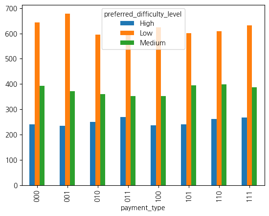

```python
grouped.plot(kind = 'bar',stacked = False)
```

### 선택 가능한 코스의 수에 제약이 있나? -> X

```python
subset = pd.pivot_table(df,
              index = 'total_completed_courses',
              columns = 'payment_type',
              values = 'user_id',
              aggfunc = 'count',
              fill_value = 0)
subset.T
```

| total_completed_courses payment_type | 1 | 2 | 3 | 4 | 5 | 6 | 7 | 8 | 9 | 10 | ... | 18 | 19 | 20 | 21 | 22 | 23 | 24 | 25 | 26 | 27 |
| --- | --- | --- | --- | --- | --- | --- | --- | --- | --- | --- | --- | --- | --- | --- | --- | --- | --- | --- | --- | --- | --- |
| 000 | 0 | 1 | 0 | 6 | 27 | 30 | 39 | 86 | 94 | 148 | ... | 45 | 23 | 14 | 7 | 3 | 6 | 1 | 2 | 0 | 0 |
| 001 | 0 | 2 | 1 | 8 | 20 | 23 | 57 | 78 | 106 | 124 | ... | 46 | 34 | 22 | 5 | 3 | 4 | 2 | 1 | 1 | 0 |
| 010 | 0 | 1 | 4 | 7 | 21 | 31 | 58 | 53 | 104 | 105 | ... | 37 | 20 | 17 | 8 | 4 | 2 | 0 | 0 | 0 | 0 |
| 011 | 0 | 1 | 3 | 10 | 15 | 22 | 55 | 68 | 100 | 102 | ... | 45 | 24 | 10 | 7 | 1 | 4 | 2 | 0 | 1 | 1 |
| 100 | 0 | 1 | 6 | 10 | 18 | 34 | 62 | 66 | 90 | 117 | ... | 42 | 23 | 17 | 3 | 3 | 2 | 0 | 2 | 1 | 1 |
| 101 | 0 | 1 | 3 | 4 | 24 | 37 | 60 | 80 | 100 | 99 | ... | 41 | 24 | 10 | 12 | 5 | 3 | 1 | 0 | 0 | 0 |
| 110 | 0 | 2 | 3 | 7 | 19 | 31 | 52 | 75 | 113 | 126 | ... | 34 | 23 | 17 | 6 | 10 | 4 | 3 | 0 | 2 | 0 |
| 111 | 1 | 1 | 3 | 8 | 11 | 30 | 59 | 93 | 99 | 123 | ... | 36 | 19 | 8 | 14 | 1 | 2 | 3 | 2 | 0 | 1 |

8 rows × 27 columns

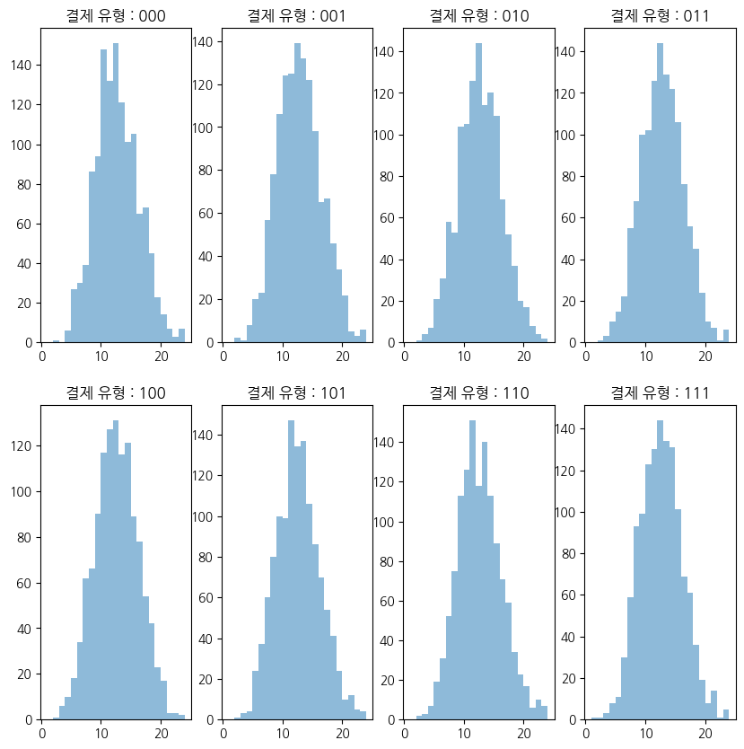

```python
fig, axes = plt.subplots(2,4,figsize= (10,10))
axes = axes.ravel()

i=0
for payment_type, subset in df.groupby('payment_type'):
    axes[i].hist(subset['total_completed_courses'],bins = range(1,25,1),alpha = 0.5, label = payment_type)
    axes[i].set_title(f"결제 유형 : {payment_type}")
    i += 1
plt.show()
```

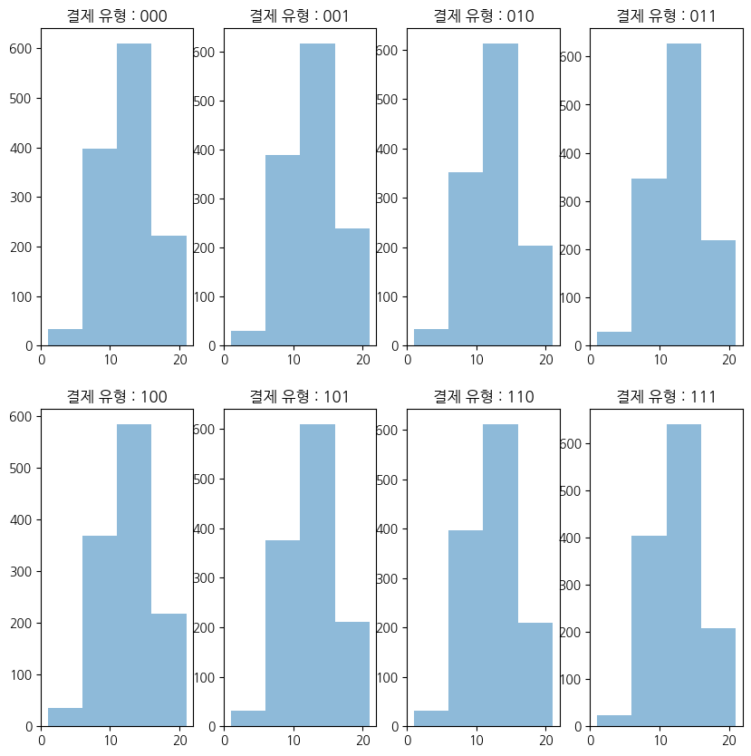

```python
fig, axes = plt.subplots(2,4,figsize= (10,10))
axes = axes.ravel()

i=0
for payment_type, subset in df.groupby('payment_type'):
    axes[i].hist(subset['total_completed_courses'],bins = range(1,25,5),alpha = 0.5, label = payment_type)
    axes[i].set_title(f"결제 유형 : {payment_type}")
    i += 1
plt.show()
```

### 결제하면 광고를 안 보는 식인가? -> 알 수 없음

```
- 영상 광고라면 로그인 시간과 학습 시간에 영향을 줄 수 있겠으나, 영상이 아닌 배너, 사진 같이 X를 누르고 사라지는 광고라면 알 수 없음
```

```python
df.groupby(['payment_type'])[['average_login_time','average_time_per_learning_session']].mean()
```

| payment_type | average_login_time | average_time_per_learning_session |
| --- | --- | --- |
| 000 | 14.925603 | 52.193572 |
| 001 | 15.037455 | 57.771236 |
| 010 | 14.933905 | 54.208172 |
| 011 | 14.868434 | 55.690510 |
| 100 | 15.056146 | 57.312095 |
| 101 | 15.028885 | 54.531108 |
| 110 | 15.055349 | 53.506295 |
| 111 | 15.042775 | 54.195952 |

```python
cut_bins = np.arange(0,30,2) #login_time으로 pivot table을 만들 경우 범위가 너무 다양해지므로 구간을 새로이 제작한다
interval = list(map(lambda x: int(x), np.arange(1,15)))
df['avg_login_interval'] = pd.cut(df['average_login_time'],bins = cut_bins,labels = interval)
```

```python
pd.pivot_table(df,
              index = 'avg_login_interval',
              columns = 'payment_type',
              values = 'user_id',
              aggfunc = 'count')
```

| payment_type avg_login_interval | 000 | 001 | 010 | 011 | 100 | 101 | 110 | 111 |
| --- | --- | --- | --- | --- | --- | --- | --- | --- |
| 1 | 0 | 0 | 0 | 0 | 0 | 0 | 0 | 0 |
| 2 | 1 | 1 | 1 | 1 | 0 | 0 | 0 | 1 |
| 3 | 1 | 3 | 3 | 2 | 0 | 0 | 0 | 1 |
| 4 | 13 | 13 | 9 | 17 | 12 | 8 | 12 | 9 |
| 5 | 52 | 46 | 38 | 39 | 57 | 44 | 52 | 44 |
| 6 | 139 | 133 | 133 | 160 | 129 | 124 | 134 | 125 |
| 7 | 260 | 290 | 260 | 254 | 242 | 278 | 266 | 284 |
| 8 | 344 | 317 | 346 | 326 | 299 | 353 | 339 | 329 |
| 9 | 276 | 257 | 232 | 232 | 282 | 230 | 261 | 292 |
| 10 | 143 | 152 | 136 | 144 | 134 | 138 | 139 | 148 |
| 11 | 38 | 58 | 33 | 46 | 47 | 48 | 49 | 41 |
| 12 | 7 | 12 | 13 | 7 | 9 | 12 | 12 | 7 |
| 13 | 0 | 3 | 2 | 2 | 3 | 3 | 4 | 1 |
| 14 | 1 | 0 | 0 | 0 | 0 | 0 | 0 | 2 |

```python
fig, axes = plt.subplots(2,4,figsize= (10,10))
axes = axes.ravel()

i=0
for payment_type, subset in df.groupby('payment_type'):
    axes[i].hist(subset['total_completed_courses'],bins = range(1,25,1),alpha = 0.5, label = payment_type)
    axes[i].set_title(f"결제 유형 : {payment_type}")
    i += 1
plt.show()
```

[output not shown]

### 구독 유형에 따라 커뮤니티 참여에 제한이 있는가?

Premium type 사용자들의 커뮤니티 참여도 레벨이 1,2가 존재하지 않는다. 3부터 시작한다.  
=> 왜?  
사이트에서 커뮤니티 참여 레벨을 측정할 때, premium 구독을 한다면 이점을 주는 걸 수도?

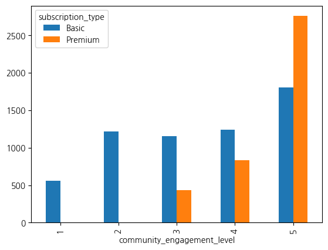

```python
pd.pivot_table(df,
              index = 'community_engagement_level',
              columns = 'subscription_type',
              values = 'user_id',
              aggfunc = 'count').plot(kind='bar',stacked=False)
plt.show()
```

## 가정

1. 결제를 한다면 어떠한 디메리트가 없애주거나, 메리트가 있을 가능성이 있음 (예시로 유튜브처럼 구독은 무료로 하며 댓글 달기, 좋아요, 커뮤니티 이용은 자유로우나, 결제를 하면 이용가능한 프리미엄이 있을 수도)
2. 결제라는 것이 구독이 아닌 어떠한 콘텐츠를 결제하는 것일 가능성이 있음 (강사와의 대화 같은)
3. target다음 달에도 구독을 계속할 사용자... 이건 구독을 연장한다고 볼 수 있는데, 구독을 하지 않는 사람에게 구독을 연장한다는 표현을 사용하지는 않을 것  
   => 이건 구독을 한 사용자들만을 수집한 데이터  
   -> 학습 플랫폼 사이트 안의, 특정한 서비스에서 가져온 데이터일 듯

# 사용자의 로그인 시간과 학습 시간

```python
df[['average_login_time','average_time_per_learning_session']].describe()
```

|  | average_login_time | average_time_per_learning_session |
| --- | --- | --- |
| count | 10000.000000 | 10000.000000 |
| mean | 14.994076 | 54.917720 |
| std | 3.001869 | 56.024310 |
| min | 2.366189 | 0.011515 |
| 25% | 13.025597 | 15.276611 |
| 50% | 14.979228 | 37.578818 |
| 75% | 16.995340 | 75.584200 |
| max | 26.998490 | 503.372616 |

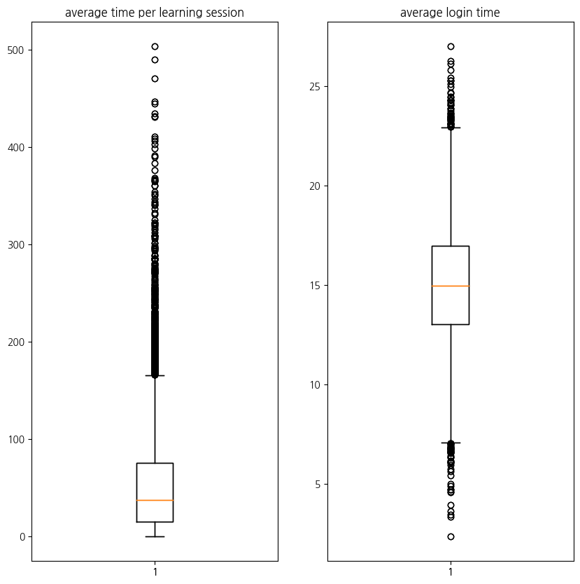

```python
fig, axes = plt.subplots(1,2,figsize= (10,10))
axes = axes.ravel()

axes[0].boxplot(df['average_time_per_learning_session'])
axes[0].set_title('average time per learning session')
axes[1].boxplot(df['average_login_time'])
axes[1].set_title('average login time')

box1 = axes[0].boxplot(df['average_time_per_learning_session'])
box2 = axes[1].boxplot(df['average_login_time'])
```

```python
#box1 = axes[0].boxplot(df['average_time_per_learning_session'])
#box2 = axes[1].boxplot(df['average_login_time'])

fliers1 = [item.get_ydata() for item in box1['fliers']]
fliers2 = [item.get_ydata() for item in box2['fliers']]

print(f'average time per learning session의 이상치 개수 : {len(fliers1[0])}')
print(f'login time의 이상치 개수 : {len(fliers2[0])}')
```

```
average time per learning session의 이상치 개수 : 512
login time의 이상치 개수 : 90
```

```python
whiskers_learn = [item.get_ydata() for item in box1['whiskers']]
print(whiskers_learn)
# max = 165.42
```

```
[array([1.52766113e+01, 1.15147969e-02]), array([ 75.5842005 , 165.42079575])]
```

```python
whiskers_login = [item.get_ydata() for item in box2['whiskers']]
print(whiskers_login)
# max = 22.92
```

```
[array([13.02559703,  7.09570601]), array([16.99534047, 22.92332603])]
```

### boxplot이 두 데이터 모두에 이상치가 있다고 하나, 조치 하지 않는다

=> 전자의 learning session은 대략 512명의 데이터가 이상치라 하나, 학습 시간이 길다는 것은 학습을 몰아서 하는 편이라 추측 가능함  
=> 후자의 login time은 로그인 하자마자 학습으로 바로 넘어갈 수도 있으며, 로그인 후 잠시 자리를 비울 가능성이 있고 / 로그인 시간이 긴 것은 이벤트나 커뮤니티 등의 활동을 할 수 있음

- 사용자의 로그인 시간이 학습 시간에 포함되어 있지 않다 -> 로그인과 학습을 별도로 취급함.
- 로그인한 사람이 학습을 듣지 않는다면 무엇을 할까?  
  -> 로그인 시간이 짧으면 -> 바로 학습으로 넘어갈 수 있을 것이고  
  -> 로그인 시간이 길다 -> 콘텐츠 탐색, 커뮤니티, 이벤트 참여 등등...의 활동이 있을 수도 있음  
  -> 그러면 로그인 시간이 길면 혜택을 받기 위해 구독을 할 수 있지 않을까?

## 로그인 시간이 긴 사람들이 커뮤니티 참여도가 높을 것이다?

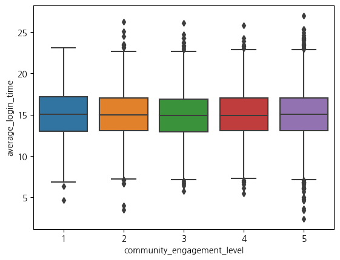

```python
sns.boxplot(x = df['community_engagement_level'],
           y = df['average_login_time'])
```

```python
grouped = df.groupby('community_engagement_level')['average_login_time']
for name, group in grouped:
    q1 = group.quantile(0.25)
    q3 = group.quantile(0.75)
    iqr = q3 - q1
    lower_bound = q1 - 1.5 * iqr
    upper_bound = q3 + 1.5 * iqr
    outliers = group[(group < lower_bound) | (group > upper_bound)]
    upper_outliers = group[(group > upper_bound)]
    lower_outliers = group[(group < lower_bound)]
    print(f"커뮤티니 참여도 {name}의 이상치 개수 : {len(outliers)}")  # 이상치 : {list(outliers)}")
    print(f"커뮤티니 참여도 {name}의 upper_bound 이상의 이상치 개수 : {len(upper_outliers)}")
    print(f"커뮤티니 참여도 {name}의 lower_bound 아래의 이상치 개수 : {len(lower_outliers)}")
    print('')
```

```
커뮤티니 참여도 1의 이상치 개수 : 2
커뮤티니 참여도 1의 upper_bound 이상의 이상치 개수 : 0
커뮤티니 참여도 1의 lower_bound 아래의 이상치 개수 : 2

커뮤티니 참여도 2의 이상치 개수 : 14
커뮤티니 참여도 2의 upper_bound 이상의 이상치 개수 : 8
커뮤티니 참여도 2의 lower_bound 아래의 이상치 개수 : 6

커뮤티니 참여도 3의 이상치 개수 : 15
커뮤티니 참여도 3의 upper_bound 이상의 이상치 개수 : 10
커뮤티니 참여도 3의 lower_bound 아래의 이상치 개수 : 5

커뮤티니 참여도 4의 이상치 개수 : 14
커뮤티니 참여도 4의 upper_bound 이상의 이상치 개수 : 7
커뮤티니 참여도 4의 lower_bound 아래의 이상치 개수 : 7

커뮤티니 참여도 5의 이상치 개수 : 45
커뮤티니 참여도 5의 upper_bound 이상의 이상치 개수 : 22
커뮤티니 참여도 5의 lower_bound 아래의 이상치 개수 : 23
```

### 로그인 시간이 긴 사람들이 커뮤니티 참여도가 높을 것이다?

=> 커뮤니티 참여도가 5인 사람들에게서 높은 이상치가 좀 더 관찰이 되긴 함 하지만 동시에 낮은 이상치 개수도 많이 나타남  
--> 하지만 이는 단순히 community engagment_level이 높은 삶들이 많아서 관찰되는 것이라 볼 수도 있음

```python
df.groupby('community_engagement_level')[['user_id']].count().T
```

| community_engagement_level | 1 | 2 | 3 | 4 | 5 |
| --- | --- | --- | --- | --- | --- |
| user_id | 559 | 1219 | 1588 | 2070 | 4564 |

## 로그인 시간이 긴 사람들이 구독 연장률이 높을 것이다?

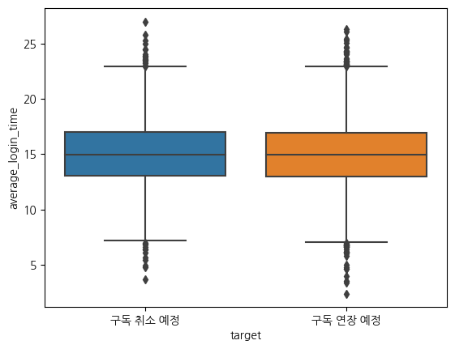

```python
sns.boxplot(x=df['target'],
           y = df['average_login_time'])
```

# 서비스 구독 예정자와 아닌 사람의 차이

```python
df['target'][df['target']==1] = '구독 연장 예정'
df['target'][df['target']==0] = '구독 취소 예정'
```

```
<BarContainer object of 2 artists>
```

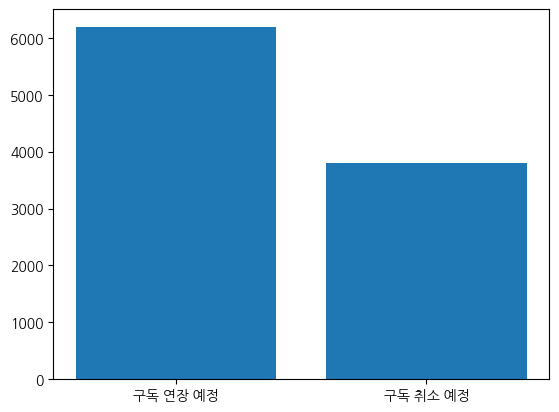

```python
plt.bar(df['target'].value_counts().index, df['target'].value_counts(),label = ['0','1'])
```

```python
df[df['target']=='구독 연장 예정']['average_login_time']
```

```
1       18.453224
2       16.195228
3       17.628656
4       21.390656
6       10.629897
          ...
9994    11.187836
9995    14.727623
9996    19.374054
9997    18.240978
9998    18.783800
Name: average_login_time, Length: 6199, dtype: float64
```

```python
plt.boxplot?
```

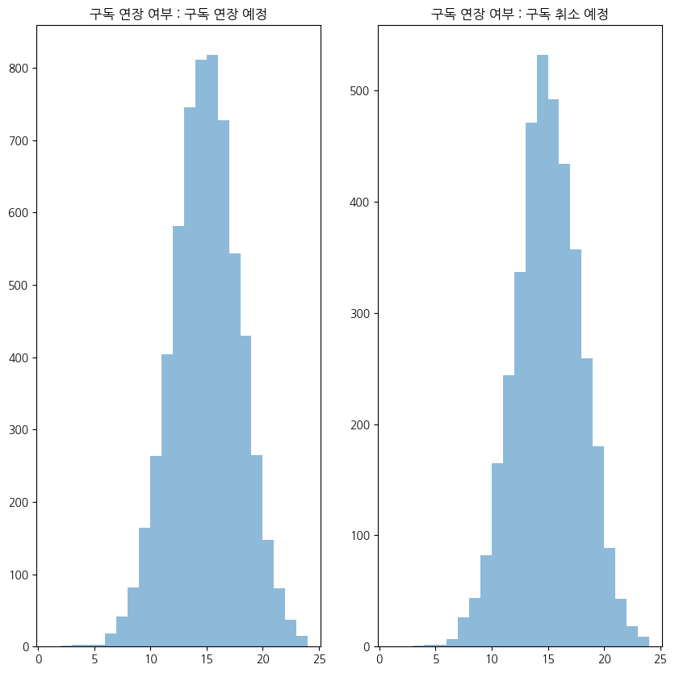

```python
fig, axes = plt.subplots(1,2,figsize= (10,10))
axes = axes.ravel()

i=0
for payment_type, subset in df.groupby('target'):
    axes[i].hist(subset['average_login_time'],bins = range(1,25),alpha = 0.5, label = payment_type)
    axes[i].set_title(f"구독 연장 여부 : {payment_type}")
    i += 1
plt.show()
```

## 구독을 취소하는 사람들은 활동적인 학습 일수가 상대적으로 적지 않을까?!

```python
chart = sns.boxplot(pd.pivot_table(df,
              index = 'monthly_active_learning_days',
              columns = 'target',
              values = 'user_id',
              aggfunc = 'average'))
chart.set_xticklabels(chart.get_xticklabels(),rotation = 45)
chart.set_title('결제 유형 별 학습 완료한 과목 수 ')
```

[output not shown]

```python
df['monthly_active_learning_days'].value_counts
```

```python
df.groupby('target')[['monthly_active_learning_days']].mean()
```

### 구독을 취소하는 사람들은 활동적인 학습 일수가 상대적으로 적지 않을까?!

=> 평균은 큰 차이 없음

### 학습 구간 별로는 좀 다를 수도 있지 않을까... 했는데

```python
cut_bins = np.arange(1,30,6)
interval = list(map(lambda x: int(x),np.arange(1,len(cut_bins))))
df['월간 학습 구간'] = pd.cut(df['monthly_active_learning_days'],bins = cut_bins,labels = interval)
```

```python
df.groupby('target')[['monthly_active_learning_days']].mean()
```

| target | monthly_active_learning_days |
| --- | --- |
| 구독 연장 예정 | 12.571866 |
| 구독 취소 예정 | 12.502236 |

```python
pd.pivot_table(df,
              index = '월간 학습 구간',
              columns = 'target',
              values = 'monthly_active_learning_days',
              aggfunc = 'mean')
```

| target 월간 학습 구간 | 구독 연장 예정 | 구독 취소 예정 |
| --- | --- | --- |
| 1 | 4.517647 | 4.515369 |
| 2 | 10.435287 | 10.440299 |
| 3 | 16.500333 | 16.528455 |
| 4 | 22.030325 | 21.952010 |

#### 학습 구간 별로는 좀 다를 수도 있지 않을까... 했는데

```
[]
```

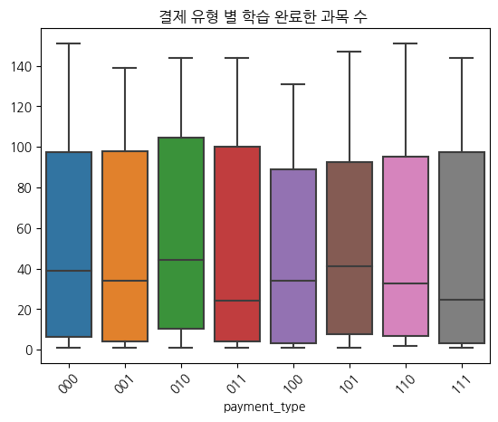

```python
chart = sns.boxplot(pd.pivot_table(df,
              index = 'total_completed_courses',
              columns = 'payment_type',
              values = 'user_id',
              aggfunc = 'count'))
chart.set_xticklabels(chart.get_xticklabels(),rotation = 45)
chart.set_title('결제 유형 별 학습 완료한 과목 수 ')
plt.plot()
```